# Assignment2

2023-03-7

## Question 1

We need to determine if the movies produced by company 2 are longer than the movies produced by company 1, by more than 10 minutes, against the alternative hypothesis that the difference is less than 10 minutes. First, let’s initialize the data.

```r
company1 <- c(102, 86, 98, 109, 92)
company2 <- c(81, 165, 97, 134, 92, 87, 114)
```

We should check the normality of the data, as it is a key assumption for many tests we would like to run.

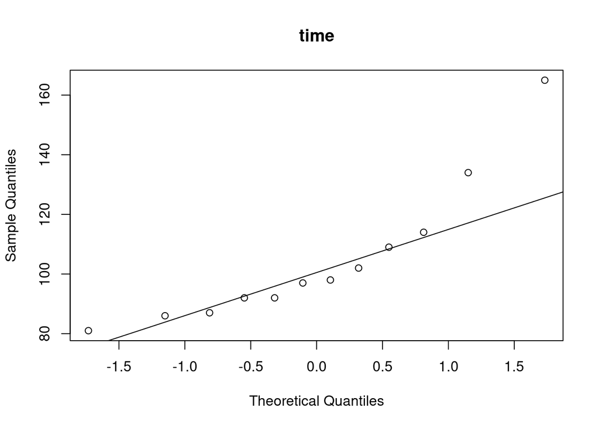

```r
data <- data.frame(company = rep(c("1", "2"), c(length(company1), length(company2))),
                   time = c(company1, company2))

# Create a normal QQ plot for time variable
qqnorm(data$time, main='time')
qqline(data$time) # Add reference line
```

As the qqplot is mostly linear (though it is hard to be certain with such a small sample), then we can assume normality, which is a help for using F and T tests.

Now, we can compare the variance of the two samples; before we compare the means we must know if the variances are substantially different. To do this we can use an F test.

First we should check the quantiles of the F distribution so that we can know how significant the result of our F test is.

```r
qf(0.95, 6,4)
```

```
## [1] 6.163132
```

```r
var.test(company2, company1, alternative = "two.sided")
```

```
##
##  F test to compare two variances
##
## data:  company2 and company1
## F = 11.591, num df = 6, denom df = 4, p-value = 0.03298
## alternative hypothesis: true ratio of variances is not equal to 1
## 95 percent confidence interval:
##   1.260208 72.176064
## sample estimates:
## ratio of variances
##           11.59052
```

This tells us that we can be quite confident that the variance of the populations from which we draw the samples are likely to be different, meaning we shouldn’t use Student’s t test, but instead Welch’s t test.

Carrying out the t test (and checking the critical value for our current comparison) to check the difference in means:

```r
qt(0.9, 10)
```

```
## [1] 1.372184
```

```r
t.test(company2, company1, alternative="less", mu=10, conf.level=0.9)
```

```
##
##  Welch Two Sample t-test
##
## data:  company2 and company1
## t = 0.215, df = 7.3756, p-value = 0.5822
## alternative hypothesis: true difference in means is less than 10
## 90 percent confidence interval:
##      -Inf 29.62057
## sample estimates:
## mean of x mean of y
##     110.0      97.4
```

We can see from the result of the test that our p value under the null hypothesis is rather high (0.5822), and since we have a 0.1 confidence interval we can accept the null hypothesis that the movies from company 2 are 10 minutes longer.

We can also use a boxplot:

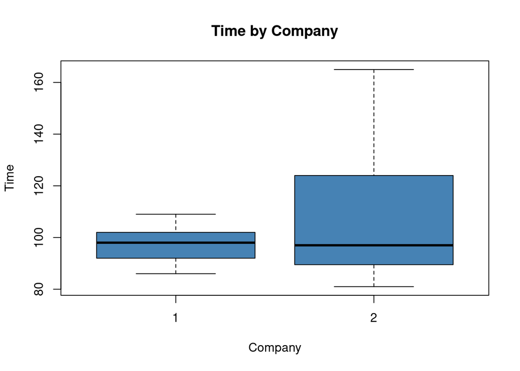

```r
boxplot(time ~ company,
        data = data,
        col = "steelblue",
        main = "Time by Company",
        xlab = "Company",
        ylab = "Time")
```

This displays what we observed earlier, company 2’s larger variance, as well as its larger mean.

## Question 2

First lets load our data

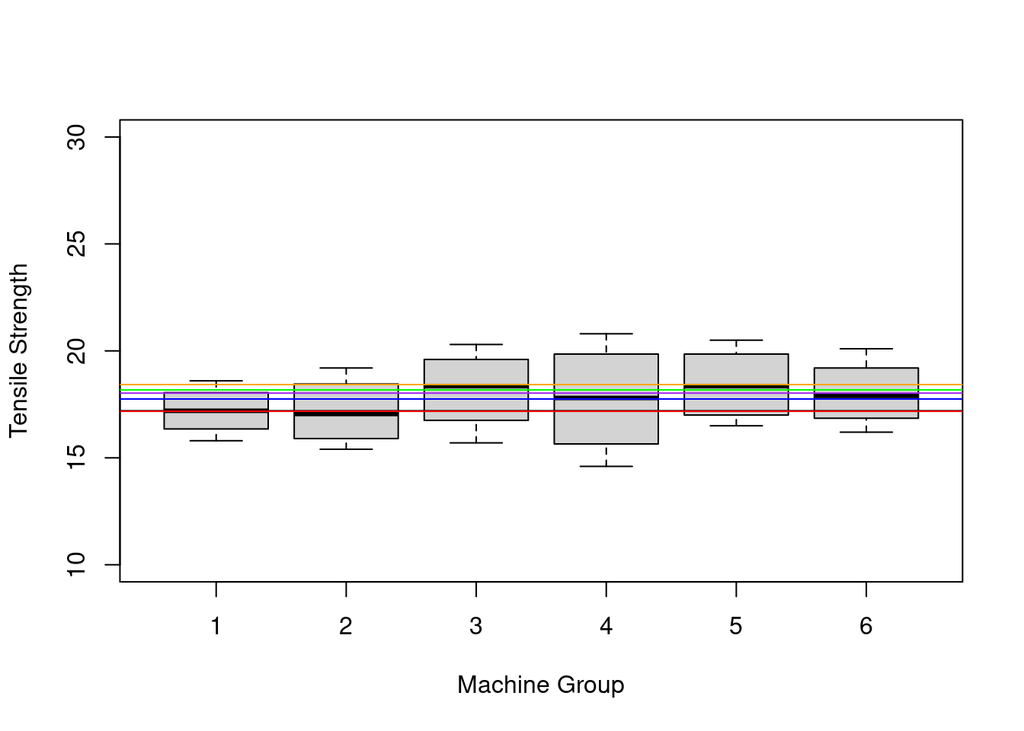

```r
# Create a vector of tensile strength measurements
tensile <- c(17.5, 16.9, 15.8, 18.6,
             16.4, 19.2, 17.7, 15.4,
             20.3, 15.7, 17.8, 18.9,
             14.6, 16.7, 20.8, 18.9,
             17.5, 19.2, 16.5, 20.5,
             18.3, 16.2 ,17.5 ,20.1)

# Create a vector of machine labels
machine <- factor(rep(1:6 , each =4))

# Create a data frame with tensile and machine columns
data <- data.frame(tensile , machine)

# Plot tensile strength by machine group
plot(machine , tensile , ylim = c(10 , 30) , ylab = "Tensile Strength" , xlab = "Machine Group" ,
pch = 21 , bg = as.numeric(machine))
abline(h = mean(tensile[machine == 1]))
abline(h = mean(tensile[machine == 2]) , col = "red")
abline(h = mean(tensile[machine == 3]) , col = "green")
abline(h = mean(tensile[machine == 4]) , col = "blue")
abline(h = mean(tensile[machine == 5]) , col = "orange")
abline(h = mean(tensile[machine == 6]) , col = "purple")
```

We can see that there is some difference in machine variance and mean tensile strength.

let’s check normality:

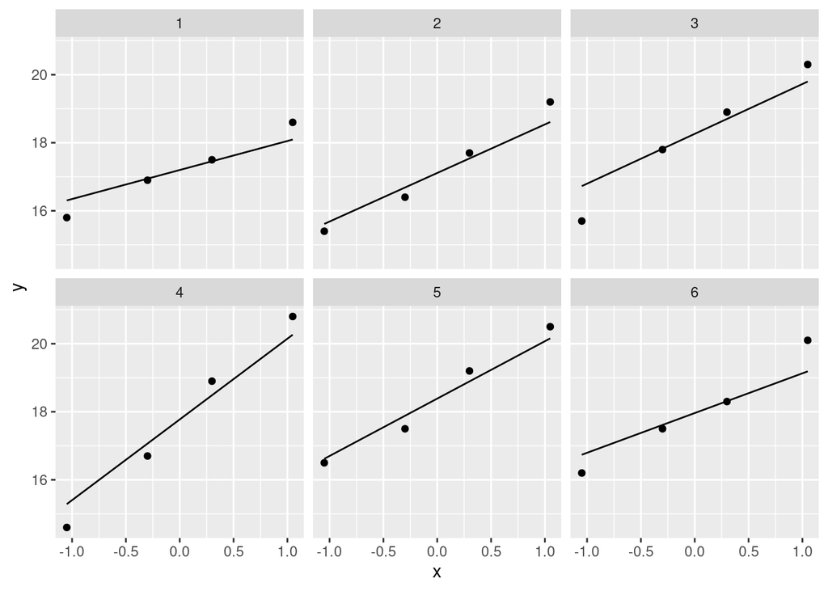

```r
# Load the ggplot2 package
library(ggplot2)

# Create a qqplot for each machine group
ggplot(data , aes(sample = tensile)) +
  geom_qq() +
  geom_qq_line() +
  facet_wrap(~ machine)
```

Seems normal!

next we check the variances:

```r
# Calculate the variance of tensile strength for each machine group
tapply(data$tensile , data$machine , var)
```

```
##        1        2        3        4        5        6
## 1.366667 2.709167 3.769167 7.216667 3.155833 2.662500
```

They are quite different! So a default anova (which assumes similar variances) won’t be appropriate. But we can use Welch’s anova instead.

```r
# Perform Welch's ANOVA on tensile strength by machine group
oneway.test(tensile ~ machine , data = data , var.equal = FALSE)
```

```
##
##  One-way analysis of means (not assuming equal variances)
##
## data:  tensile and machine
## F = 0.33231, num df = 5.0000, denom df = 8.3181, p-value = 0.8803
```

```r
# Next we perform the Kruskal-Wallis test
kruskal.test(tensile ~ machine)
```

```
##
##  Kruskal-Wallis rank sum test
##
## data:  tensile by machine
## Kruskal-Wallis chi-squared = 1.7395, df = 5, p-value = 0.8839
```

Judging by these outputs, there is no reason to consider the difference between machines significant at alpha = 0.05

## Question 3

First load the data

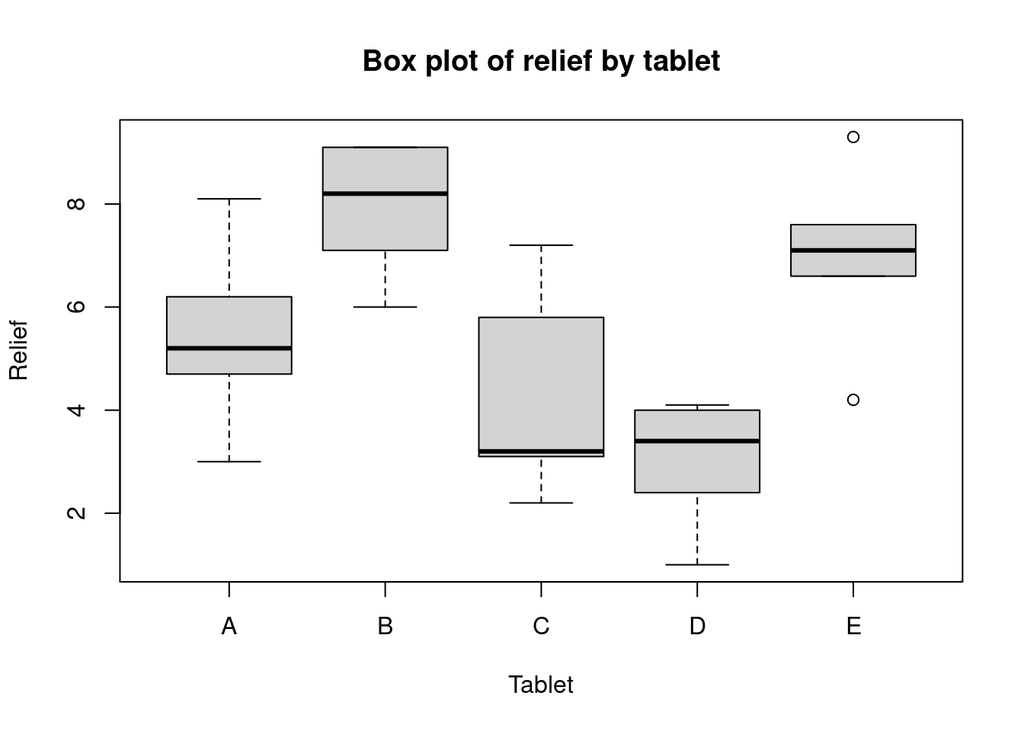

```r
# Create a data frame with the tablet and relief data
data <- data.frame(
  tablet = rep(c("A", "B", "C", "D", "E"), each = 5),
  relief = c(5.2, 4.7, 8.1, 6.2, 3.0,
             9.1, 7.1, 8.2, 6.0, 9.1,
             3.2, 5.8, 2.2, 3.1, 7.2,
             2.4, 3.4, 4.1, 1.0, 4,
             7.1, 6.6 ,9.3 ,4.2 ,7.6)
)

# Create a box plot of relief by tablet
boxplot(relief ~ tablet , data = data,
        main = "Box plot of relief by tablet",
        xlab = "Tablet",
        ylab = "Relief")
```

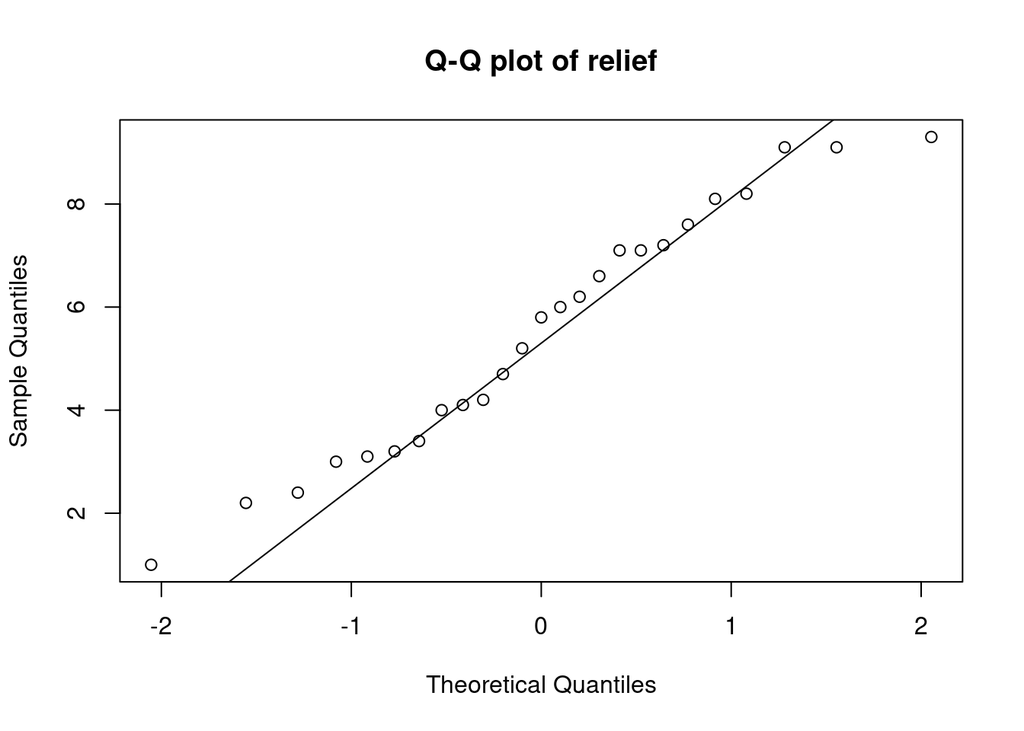

```r
# Create a qqplot of relief
qqnorm(data$relief,
       main = "Q-Q plot of relief")
qqline(data$relief)
```

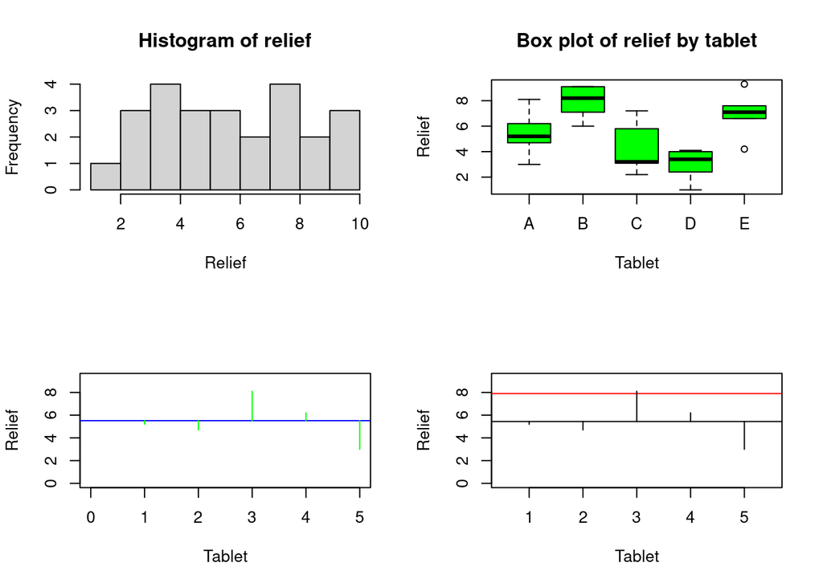

```r
# Create four plots in one window
par(mfrow=c(2,2))

# Create a histogram of relief
hist(data$relief,
     main = "Histogram of relief",
     xlab = "Relief")


# Create a box plot of relief by tablet
boxplot(relief ~ tablet , data = data,
        main = "Box plot of relief by tablet",
        xlab = "Tablet",
        ylab = "Relief",
        col="green")

# Create a scatter plot of relief by tablet with mean line and deviation lines
plot(as.numeric(data$tablet), data$relief,
     ylim=c(0,max(data$relief)),
     xlim = c(0,5),
     ylab="Relief",
     xlab="Tablet",
     pch=21,bg='red')
abline(h=mean(data$relief),col="blue")

for (i in 1:nrow(data))
{
   lines(c(i,i),c(mean(data$relief),data$relief[i]),col='green')
}

plot(as.numeric(data$tablet), data$relief,
     ylim=c(0,max(data$relief)),
     xlim=c(0.5,5.5),
     ylab="Relief",
     xlab="Tablet",
     pch=21,bg = as.numeric(data$tablet))
abline(h=mean(data$relief[data$tablet=="A"]))
abline(h=mean(data$relief[data$tablet=="B"]),col="red")
index<-1:nrow(data)
for (i in index)
{
   if (data$tablet[i]=="A")
   {
      lines(c(index[i],index[i]),c(mean(data$relief[data$tablet=="A"]),data$relief[i]))
   }
   else
   {
      lines(c(index[i],index[i]),c(mean(data$relief[data$tablet=="B"]),data$relief[i]),col="red")
   }
}
```

```r
# Fit a one-way ANOVA model using relief as response and tablet as predictor
model <- aov(relief ~ tablet , data = data)

# Print the ANOVA table
summary(model)
```

```
##             Df Sum Sq Mean Sq F value Pr(>F)
## tablet       4  78.42  19.605   6.587 0.0015 **
## Residuals   20  59.53   2.977
## ---
## Signif. codes:  0 '***' 0.001 '**' 0.01 '*' 0.05 '.' 0.1 ' ' 1
```

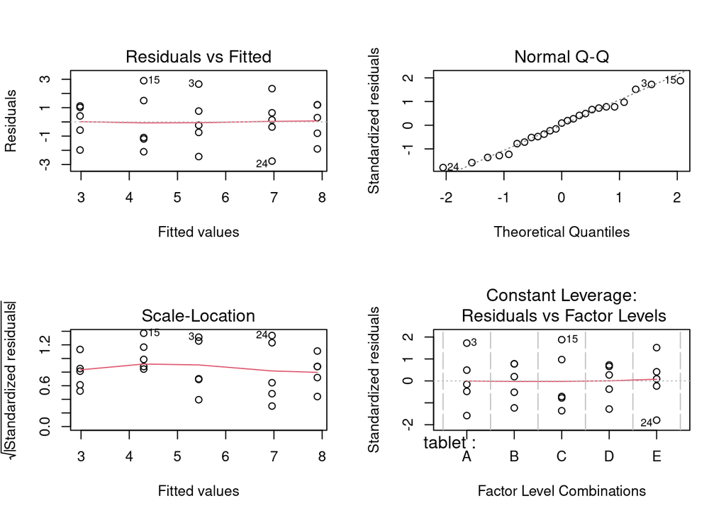

```r
plot(model)
```

We can see from the plots and the f statistic that the means are quite different, and can therefore reject the null hypothesis of equal means.